# Skrypty reprodukujące wykresy z rozdziału ,,Gramatyka języka wizualizacji historii’’

Przemyslaw Biecek

22 December 2015

# Przygotowanie

```r
library(ggplot2)
library(scales)
library(dplyr)
library(archivist)

# store everything in the archivist repo
setLocalRepo("arepo")

q3 <- function(x) {
  a <- quantile(x, c(0.25,0.5,0.75))
  names(a) <- c("ymin", "y", "ymax")
  a
}

print.ggplot <- function(x, ...) {
  hash <- saveToRepo(x)
  cat("Load: [`archivist::aread('pbiecek/Eseje/arepo/",hash,"')`](https://github.com/pbiecek/Eseje/raw/master/arepo/gallery/",hash,".rda)\n", sep="")
  ggplot2:::print.ggplot(x, ...)
}
```

# Dane

W tym skrypcie wykorzystujemy pakiet `SmarterPoland` i zbiory danych

```r
library(SmarterPoland)
head(countries)
```

```
##               country birth.rate death.rate population continent
## 1         Afghanistan       34.1        7.7      30552      Asia
## 2             Albania       12.9        9.4       3173    Europe
## 3             Algeria       24.3        5.7      39208    Africa
## 4             Andorra        8.9        8.4         79    Europe
## 5              Angola       44.1       13.9      21472    Africa
## 6 Antigua and Barbuda       16.5        6.8         90  Americas
```

```r
head(maturaExam)
```

```
##   podstawowy.matematyka podstawowy.j.polski  rok
## 1                    19                  35 2010
## 2                    16                  43 2010
## 3                    25                  39 2010
## 4                    27                  35 2010
## 5                    27                  43 2010
## 6                    31                  42 2010
```

# Warstwy

```r
countriesMin <- countries %>%
  group_by(continent) %>%
  filter(birth.rate == min(birth.rate, na.rm=TRUE))
countriesMax <- countries %>%
  group_by(continent) %>%
  filter(birth.rate == max(birth.rate, na.rm=TRUE))

ggplot(countries, aes(x=continent, y=birth.rate, label=country)) +
  geom_violin(scale="area", fill="grey", color="white") +
  stat_summary(fun.data = "q3", geom = "crossbar",
               colour = "red", width = 0.4) +
  geom_jitter(position=position_jitter(width = .25, height = 0),
             shape=15) +
  geom_rug(sides = "l") +
  geom_text(data=countriesMin, vjust=2, color="blue3") +
  geom_text(data=countriesMax, vjust=-1, color="blue3") +
  theme_bw() + xlab("") + theme(panel.grid.major.x = element_line(color="white"))
```

Load: [`archivist::aread('pbiecek/Eseje/arepo/e02ad04b68e55035371b3b99112cdf3c')`](https://github.com/pbiecek/Eseje/raw/master/arepo/gallery/e02ad04b68e55035371b3b99112cdf3c.rda)

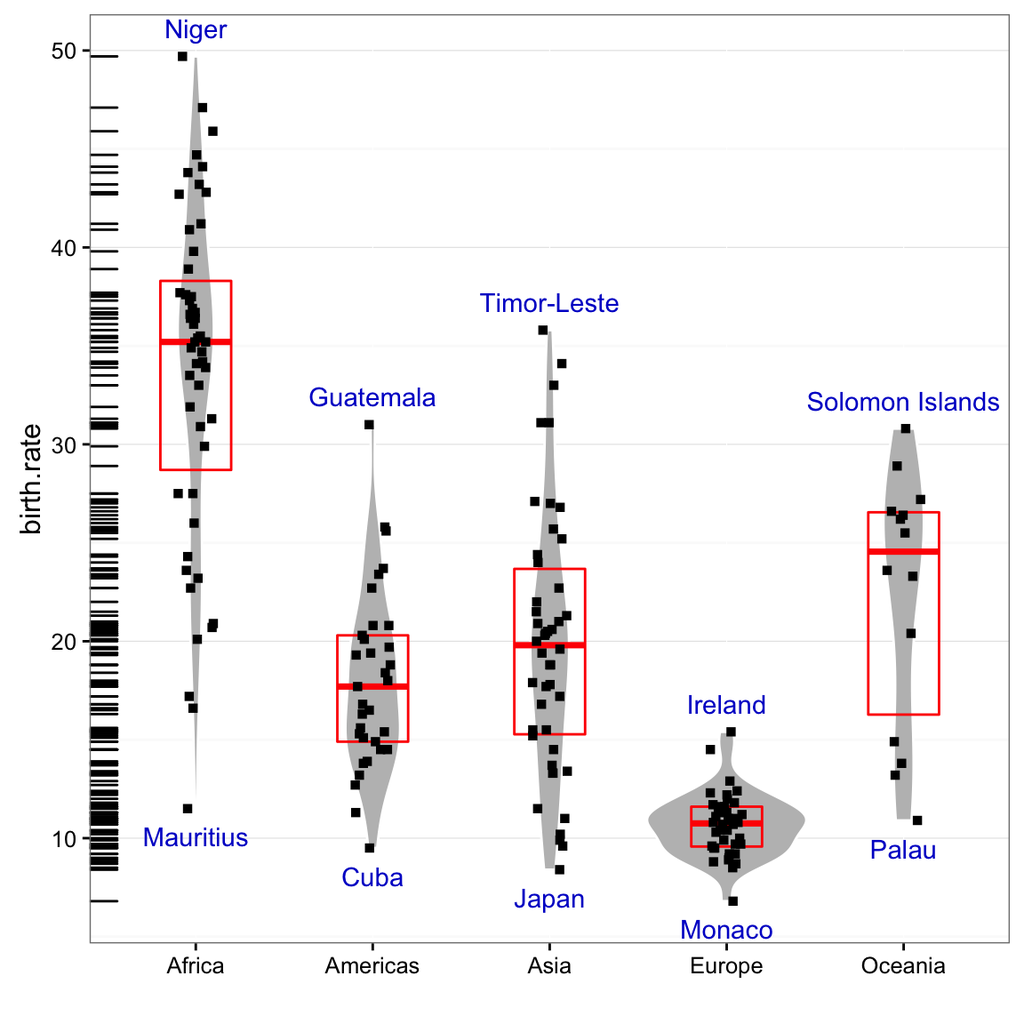

```r
ggplot(countries, aes(x=birth.rate, y=death.rate)) +
  geom_density_2d(h=c(10,10), color="grey") +
  geom_point() + coord_fixed() +
  geom_abline(intercept=0,slope=1) +
  geom_point(data=countries[132,], color="red", size=4) +
  theme_bw()
```

Load: [`archivist::aread('pbiecek/Eseje/arepo/13d5c2cf07e277c07e776473b106a1b0')`](https://github.com/pbiecek/Eseje/raw/master/arepo/gallery/13d5c2cf07e277c07e776473b106a1b0.rda)

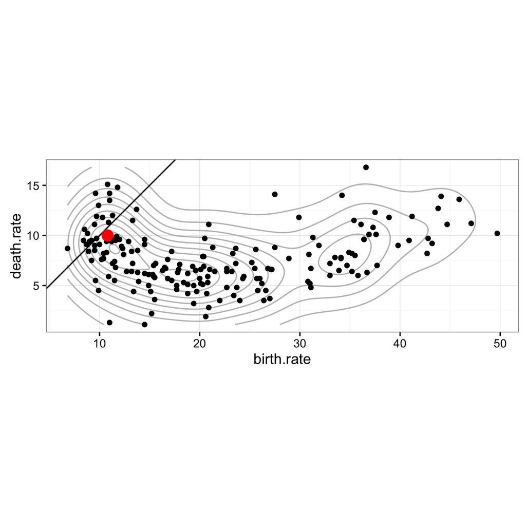

# Mapowania

```r
ggplot(countries, aes(x=birth.rate, y=death.rate)) +
  geom_point() + coord_fixed() +
  theme_bw()
```

Load: [`archivist::aread('pbiecek/Eseje/arepo/19794b19037daced210ff5c6d485d3be')`](https://github.com/pbiecek/Eseje/raw/master/arepo/gallery/19794b19037daced210ff5c6d485d3be.rda)

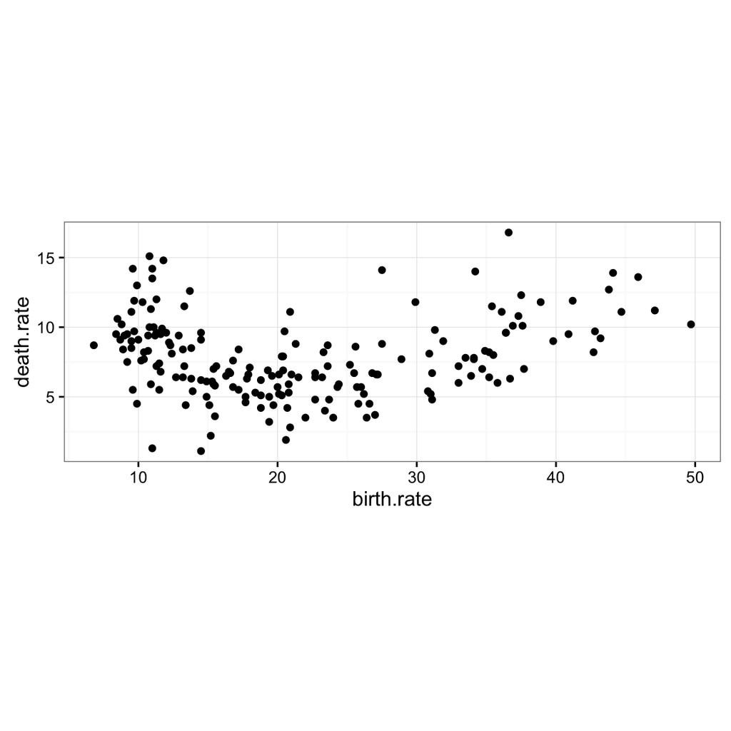

```r
ggplot(countries, aes(x=birth.rate, y=death.rate,
                      color=continent, shape=continent)) +
  geom_point() + coord_fixed() +
  theme_bw() + theme(legend.position="top")
```

Load: [`archivist::aread('pbiecek/Eseje/arepo/4d7b9c309ad4875690da61c194f5ca1f')`](https://github.com/pbiecek/Eseje/raw/master/arepo/gallery/4d7b9c309ad4875690da61c194f5ca1f.rda)

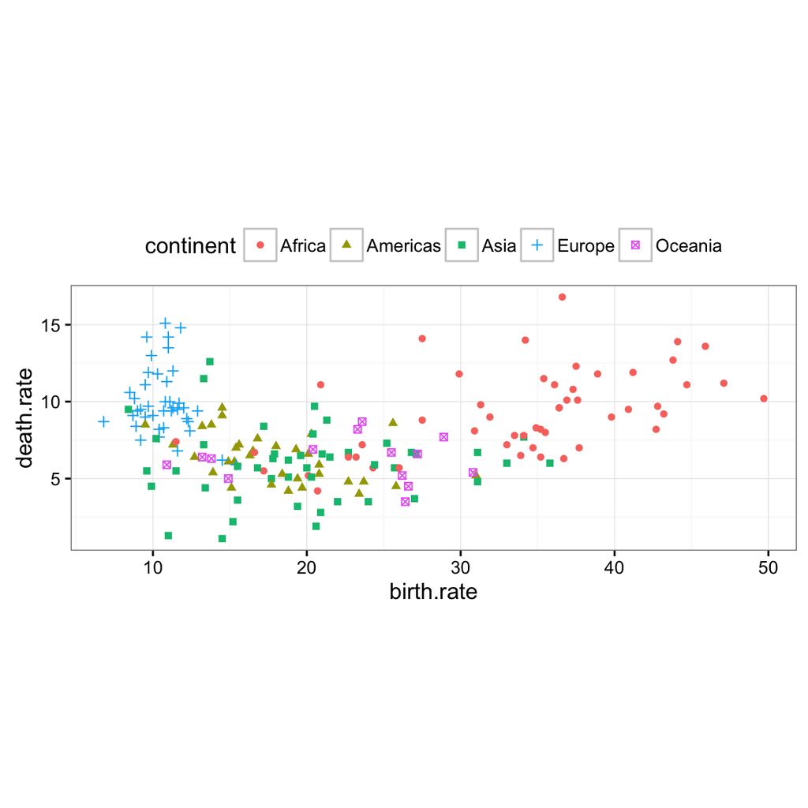

```r
countries$populationCat <- cut(countries$population,
                               c(1, 10^3, 10^4, 10^5, 10^6, 10^7),
                               labels = c("< 1M", "< 10M","< 100 M", "< 1 B", "> 1 B"), ordered_result = TRUE)

ggplot(countries, aes(x=birth.rate, y=death.rate,
                      color=continent, shape=continent,
                      size=populationCat)) +
  geom_point() + coord_fixed() +
  theme_bw() + theme(legend.position="top")
```

Load: [`archivist::aread('pbiecek/Eseje/arepo/f7bee75d70a77bd9e1ae66323afe8f6e')`](https://github.com/pbiecek/Eseje/raw/master/arepo/gallery/f7bee75d70a77bd9e1ae66323afe8f6e.rda)

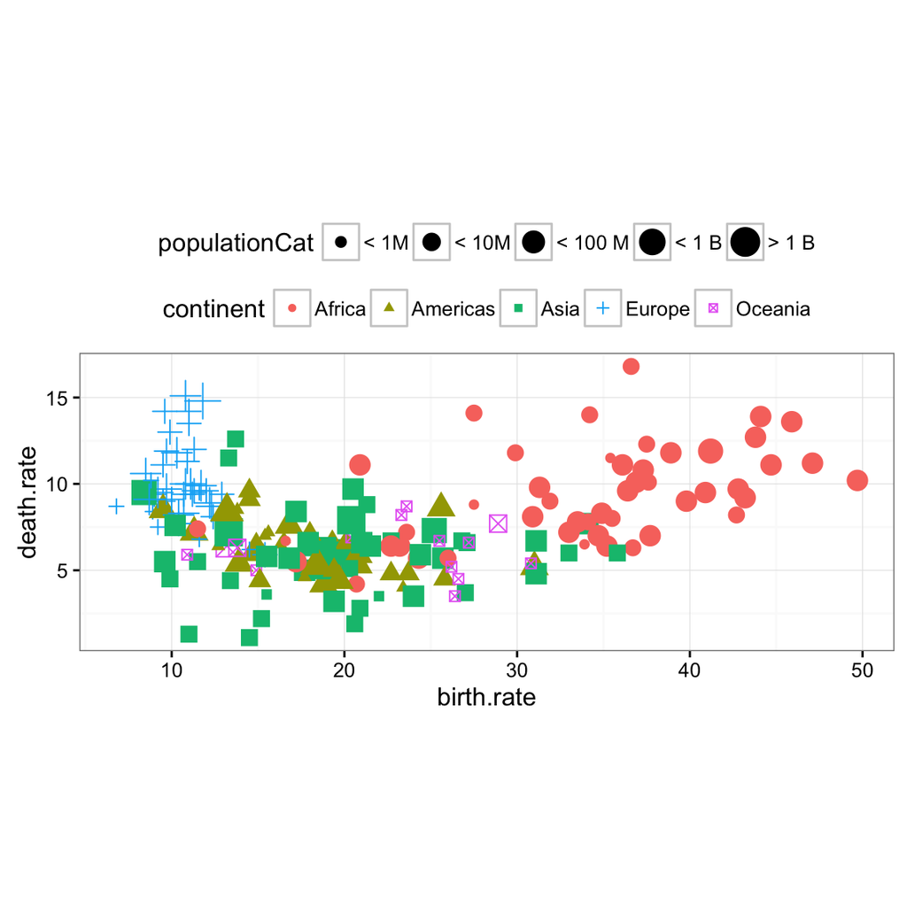

# Formy / Geometrie

## Punkty

```r
# dotplot
ggplot(countries, aes(x = continent, y = birth.rate)) +
  geom_dotplot(binaxis = "y", stackdir = "center", binwidth = 0.7) +
  theme_bw()
```

Load: [`archivist::aread('pbiecek/Eseje/arepo/ccf21a147baebcf2498c7fc44f59e882')`](https://github.com/pbiecek/Eseje/raw/master/arepo/gallery/ccf21a147baebcf2498c7fc44f59e882.rda)

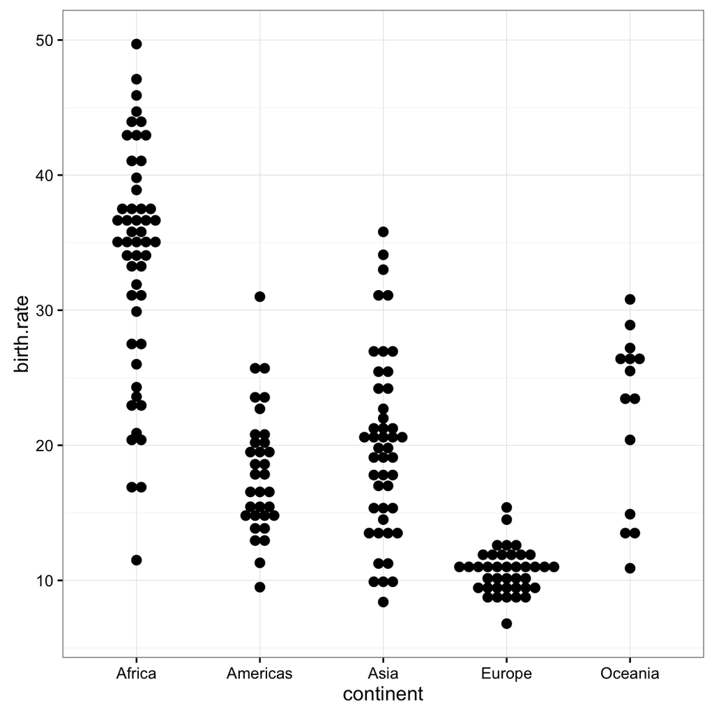

```r
# dotplot
ggplot(countries, aes(x = birth.rate, y =death.rate)) +
  geom_point() +
  theme_bw()
```

Load: [`archivist::aread('pbiecek/Eseje/arepo/4cc6027ddf39539bf985daefae7db7f5')`](https://github.com/pbiecek/Eseje/raw/master/arepo/gallery/4cc6027ddf39539bf985daefae7db7f5.rda)

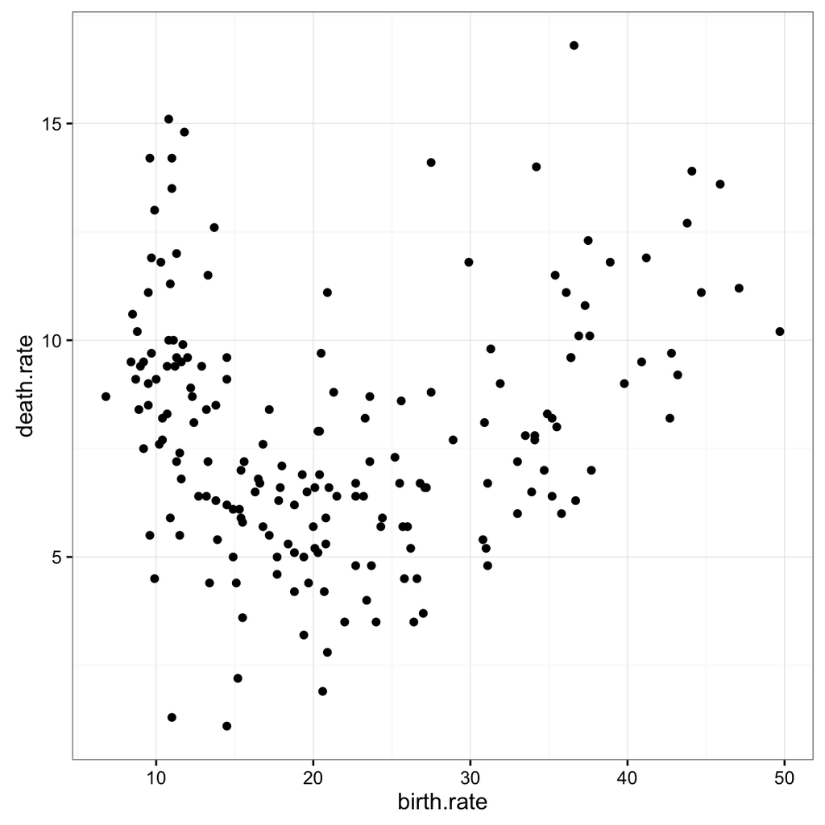

```r
# jitter
ggplot(countries, aes(x = continent, y =birth.rate)) +
  geom_jitter(position = position_jitter(width = .2)) +
  theme_bw()
```

Load: [`archivist::aread('pbiecek/Eseje/arepo/7f97f57921664fcb7d30d927575dcb34')`](https://github.com/pbiecek/Eseje/raw/master/arepo/gallery/7f97f57921664fcb7d30d927575dcb34.rda)

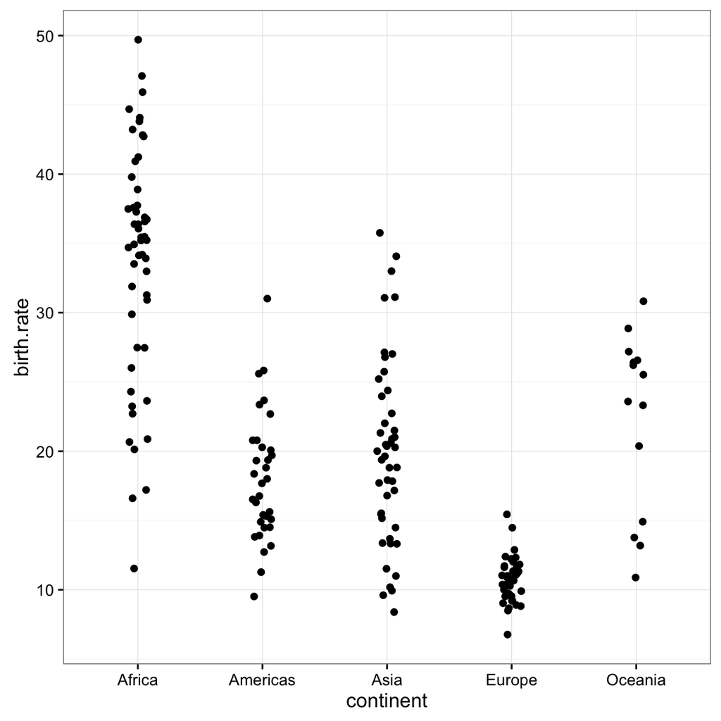

```r
# różne mapownia
ggplot() +
  geom_point(data=countries, aes(x = birth.rate, y =death.rate, shape=continent), size=4) +
  theme_bw() +
  scale_shape_manual(values=c("F","A","S","E","O")) +
  theme(legend.position=c(0.9,0.17))
```

Load: [`archivist::aread('pbiecek/Eseje/arepo/9603959bdb5fcde4916de25ac635783f')`](https://github.com/pbiecek/Eseje/raw/master/arepo/gallery/9603959bdb5fcde4916de25ac635783f.rda)

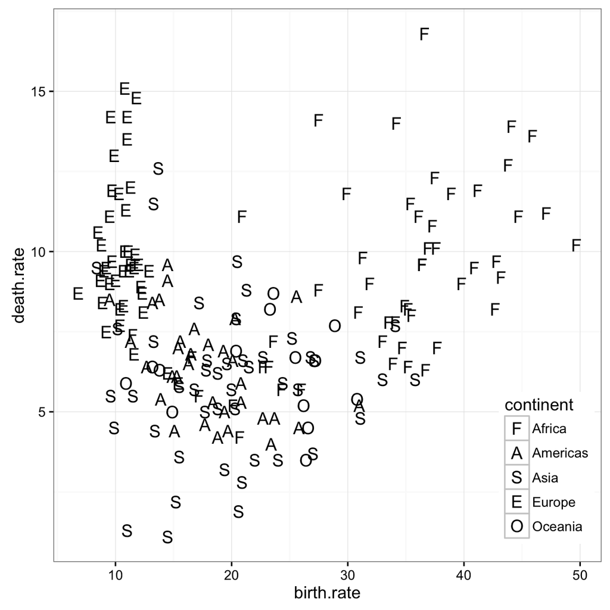

```r
ggplot() +
  geom_point(data=countries, aes(x = birth.rate, y =death.rate, color=continent), size=4, shape=19) +
  theme_bw() + scale_color_brewer(type = "qual", palette=6) +
  theme(legend.position=c(0.9,0.17))
```

Load: [`archivist::aread('pbiecek/Eseje/arepo/69e4470a064eca4faf21ecb10a9f9994')`](https://github.com/pbiecek/Eseje/raw/master/arepo/gallery/69e4470a064eca4faf21ecb10a9f9994.rda)

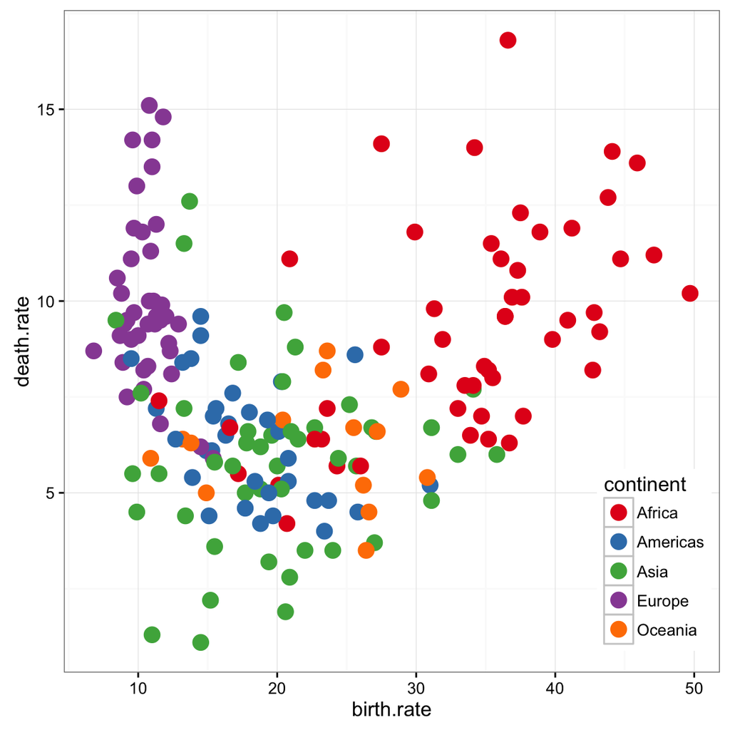

```r
ggplot() +
  geom_point(data=countries, aes(x = birth.rate, y =death.rate, size=population)) +
  scale_size_continuous(trans="sqrt", label=comma, limits=c(0,1500000)) +
  theme_bw() + theme(legend.position="none")
```

Load: [`archivist::aread('pbiecek/Eseje/arepo/0a05f31ead54caee9572292f385caed5')`](https://github.com/pbiecek/Eseje/raw/master/arepo/gallery/0a05f31ead54caee9572292f385caed5.rda)

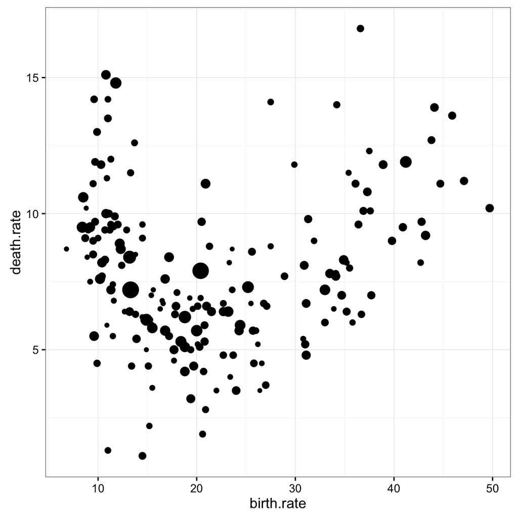

## Obszar

```r
# density
ggplot(countries, aes(x = birth.rate, fill = continent)) +
  geom_density(alpha=0.5) +
  theme_bw() + theme(legend.position=c(0.85,0.85))
```

Load: [`archivist::aread('pbiecek/Eseje/arepo/7929dd727c479b1c939b3d0c5729cdc4')`](https://github.com/pbiecek/Eseje/raw/master/arepo/gallery/7929dd727c479b1c939b3d0c5729cdc4.rda)

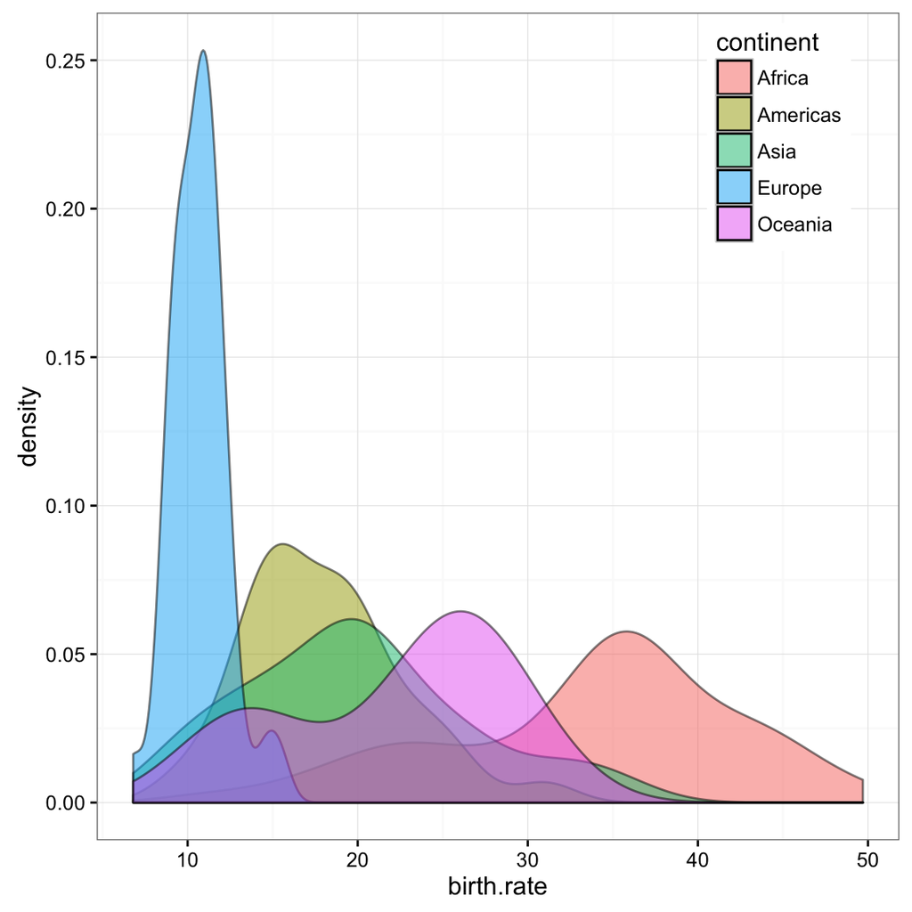

```r
# vioplot
ggplot(countries, aes(x = continent, y = birth.rate, fill=continent)) +
  geom_violin() +
  theme_bw() + theme(legend.position="none")
```

Load: [`archivist::aread('pbiecek/Eseje/arepo/26d9c58bd0ff95117e1d37aeb47512de')`](https://github.com/pbiecek/Eseje/raw/master/arepo/gallery/26d9c58bd0ff95117e1d37aeb47512de.rda)

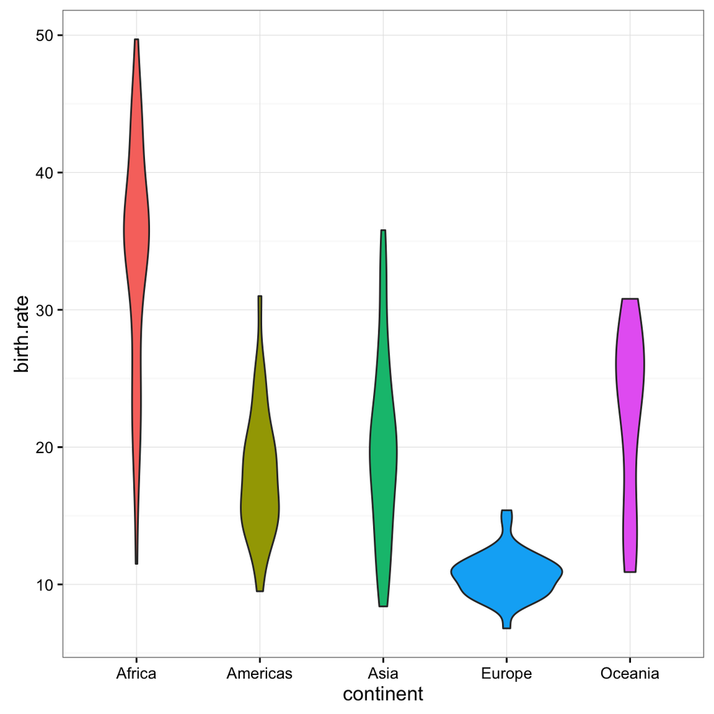

```r
# ribbon
ndf <- countries %>%
  group_by(continent) %>%
  summarise(birth.rate = weighted.mean(birth.rate, population, na.rm=TRUE),
            death.rate = weighted.mean(death.rate, population, na.rm=TRUE))

ggplot() +
  geom_ribbon(data=ndf, aes(x=continent, ymax=birth.rate, y=birth.rate, ymin=0, group=1), fill="green3") +
  geom_ribbon(data=ndf, aes(x=continent, ymax=death.rate, y=death.rate, ymin=0, group=1), fill="red3") +
  theme_bw() + xlab("") + ylab("birth.rate / death.rate")
```

Load: [`archivist::aread('pbiecek/Eseje/arepo/70366ebb679bdc0d6bee88b9056932b7')`](https://github.com/pbiecek/Eseje/raw/master/arepo/gallery/70366ebb679bdc0d6bee88b9056932b7.rda)

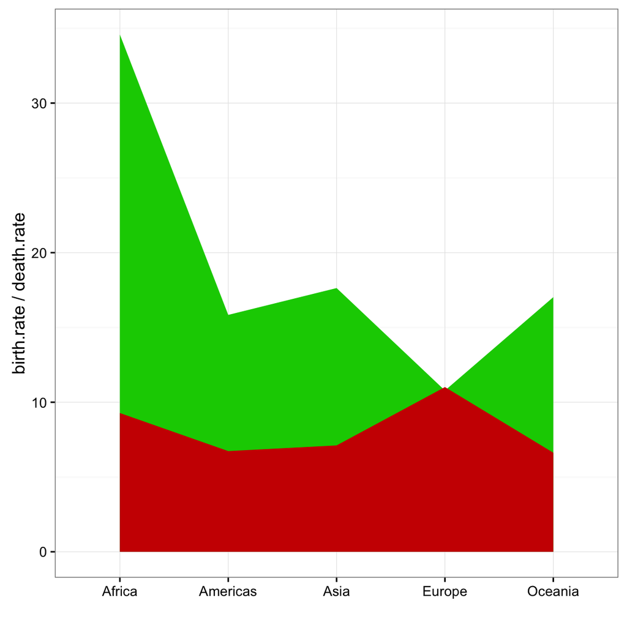

## Prostokąty

```r
continents <-
  countries %>%
  group_by(continent) %>%
  summarise(birth.rate = weighted.mean(birth.rate, w = population, na.rm=TRUE),
            death.rate = weighted.mean(death.rate, w = population, na.rm=TRUE),
            population = sum(population))

# bar
ggplot(continents, aes(x = continent, y = birth.rate)) +
  geom_bar(stat = "identity") +
  theme_bw()
```

Load: [`archivist::aread('pbiecek/Eseje/arepo/59442be9ea10e26f0b817f6ad0dd0f31')`](https://github.com/pbiecek/Eseje/raw/master/arepo/gallery/59442be9ea10e26f0b817f6ad0dd0f31.rda)

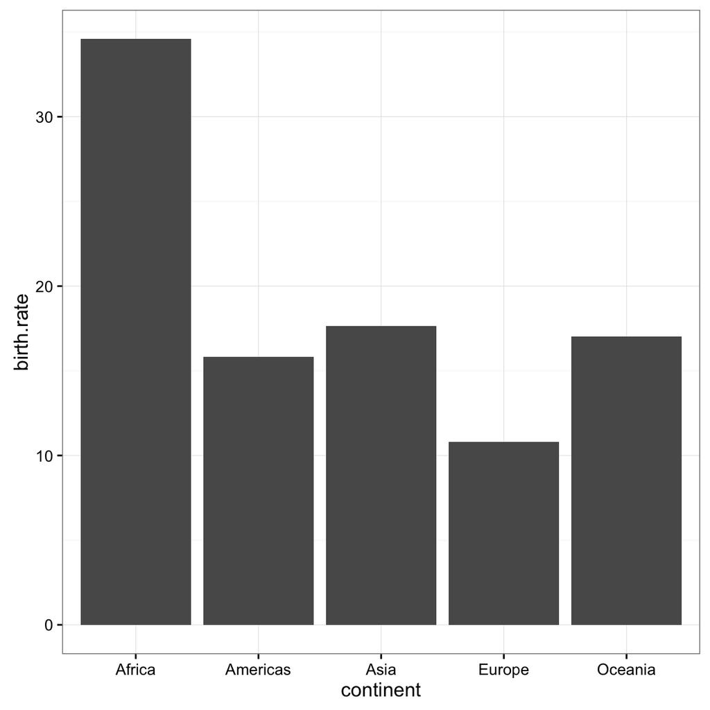

```r
continents2 <- continents %>%
  mutate(cum = cumsum(population)-population)

ggplot() +
  geom_rect(data=continents2, aes(xmin=cum, ymax=0, xmax=cum+population, ymin=birth.rate, fill=continent)) +
  geom_text(data=continents2, aes(label=continent, x=cum+population/2, y=birth.rate), vjust=-0.1) +
  theme_bw() + theme(legend.position="none") +
  xlab("population") + ylab("birth.rate")
```

Load: [`archivist::aread('pbiecek/Eseje/arepo/519b348ef25c8106739f6554d20efdd0')`](https://github.com/pbiecek/Eseje/raw/master/arepo/gallery/519b348ef25c8106739f6554d20efdd0.rda)

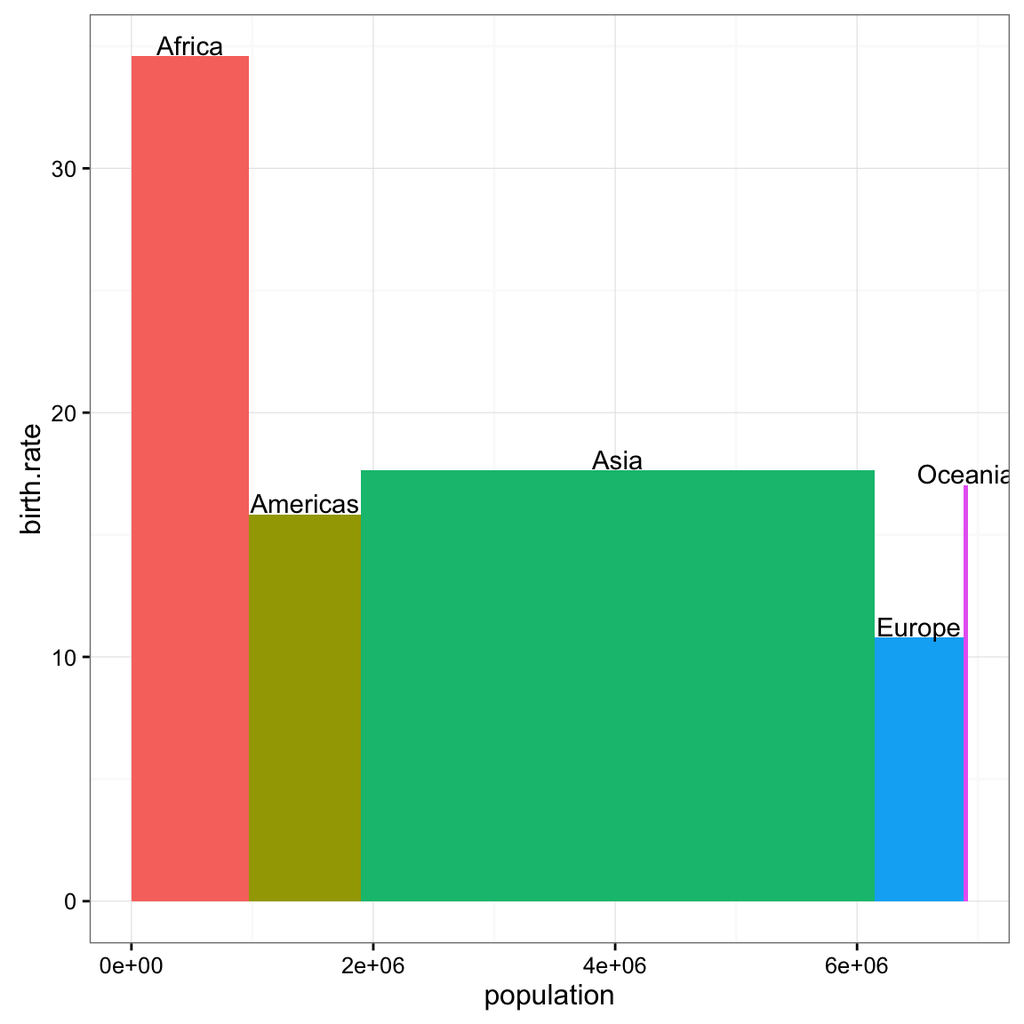

```r
ggplot() +
  geom_rect(data=continents, aes(xmin = as.numeric(factor(continent))-0.1,
                                 ymin = 0,
                                 xmax = as.numeric(factor(continent))+0.2,
                                 ymax = birth.rate),
            fill="green3") +
  geom_rect(data=continents, aes(xmin = as.numeric(factor(continent))+0.21,
                                 ymin = birth.rate - death.rate,
                                 xmax = as.numeric(factor(continent))+0.51,
                                 ymax = birth.rate),
            fill="red3") +
  geom_text(data=continents, aes(x = as.numeric(factor(continent))+0.21,
                                 y = birth.rate + 1,
                                 label = continent)) +
  geom_hline(yintercept=0) + ylab("birth.rate - death.rate") + xlab("") +
  geom_rug(data=continents, aes(x = as.numeric(factor(continent))+0.21,
                                y = birth.rate - death.rate), sides="l") +
  theme_bw() + theme(axis.text.x = element_text(color="white"),
                     axis.ticks.x = element_line(color="white"))
```

Load: [`archivist::aread('pbiecek/Eseje/arepo/ddd7f9aa123375309cd1ad9a96700df0')`](https://github.com/pbiecek/Eseje/raw/master/arepo/gallery/ddd7f9aa123375309cd1ad9a96700df0.rda)

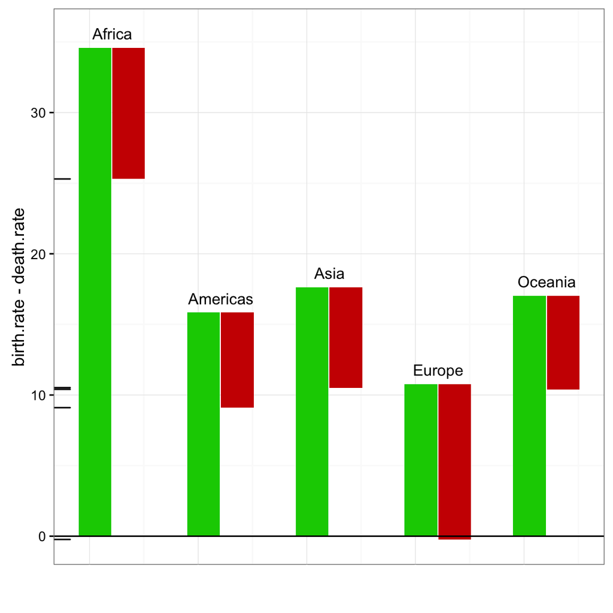

```r
# liczba krajów na kontynent
ggplot(countries, aes(x = continent, fill = continent)) +
  geom_bar() +
  theme_bw() + theme(legend.position="none") + xlab("") + ylab("Liczba krajów")
```

Load: [`archivist::aread('pbiecek/Eseje/arepo/7c0e64651d0f94435d6bb9af38289e92')`](https://github.com/pbiecek/Eseje/raw/master/arepo/gallery/7c0e64651d0f94435d6bb9af38289e92.rda)

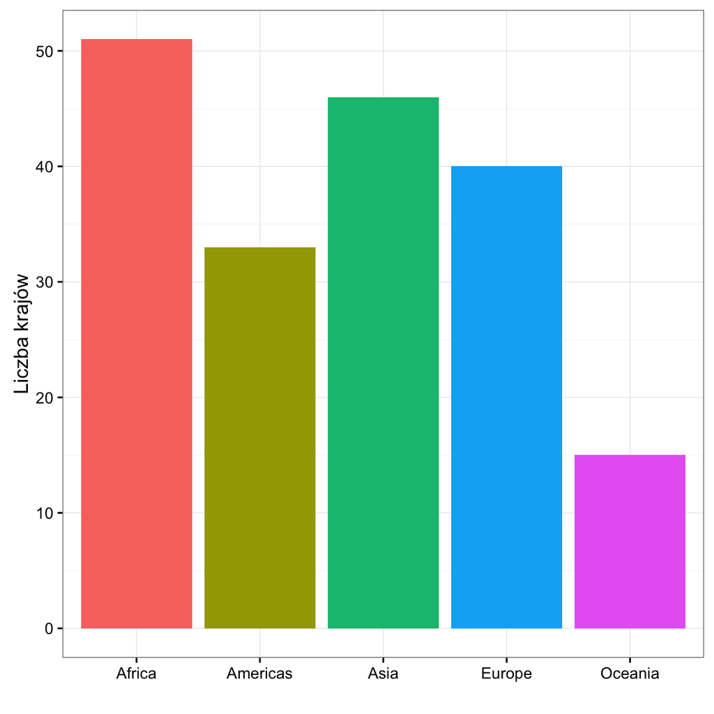

## Linie

# Statystyki

# Modyfikatory położenia

# Układ współrzędnych

# Miary / podziałki / skale

# Panele / oblicza

# Dekoracje